# Poisson log normal

Océane

1/23/2020

# Modèle linéaire généralisé : théorie

GLM en deux parties :

**Partie déterministe**: modélisation de l’espérance des observations conditionnellement aux variables explicatives

**Partie aléatoire**: modélisation de la variabilité des observations conditionnellement aux variables explicatives

Nous souhaitons modéliser l’expression des gènes (données de comptage normalisées) de 8 conditions (24 transcriptomes) à l’aide d’une loi de Poisson.

Ici, de log de l’espérance des données de compatge est estimé par une combinason linéaire des variables prédictives (qualitatives ici) : CO2 élevé ou non, bas nitrate ou fort nitrate, carence en fer ou non. Nous prenons comme individus l’ensemble des gènes différentiellement exprimés dans au moins d’une des analyses DE sur les 12 réalisées au prélable.

L’objectif est de voir si des coefficients propores aux facteurs ou leurs interactions sont significatifs, renseignant sur un effet global de ces facteurs sur les gènes DE.

# Implémentation et résultats

## Sur l’ensemble des gènes

On utilise le même gene pour faire plusieurs predictions (24 fois pas gene, car une fois dans chaque transcriptome disponible), dans des conditions diffrentes, cele ne nuit t il pas à l’hypothèse d’indépendance des individus?

```r
load("./normalized.count_At.RData")
load("./DEgenesAllAt.RData")

glmData <- melt(round(normalized.count[DEgenes, ], 0))
colnames(glmData) <- c("gene", "Condition", "Counts")

groups <- str_split_fixed(glmData$Condition, "_", 2)[, 1]
glmData$Co2 <- str_split_fixed(groups, "", 3)[, 1]
glmData$nitrate <- str_split_fixed(groups, "", 3)[, 2]
glmData$fer <- str_split_fixed(groups, "", 3)[, 3]


glmData$Co2 <- ifelse(glmData$Co2 == "c", 0, 1)
glmData$nitrate <- ifelse(glmData$nitrate == "N", 0, 1)
glmData$fer <- ifelse(glmData$fer == "F", 0, 1)
glmData <- glmData[c("Counts", "Co2", "nitrate", "fer", "gene")]

head(glmData)
```

```
  Counts Co2 nitrate fer      gene
1   6868   0       0   0 AT1G03870
2    655   0       0   0 AT1G05660
3    963   0       0   0 AT1G06120
4    600   0       0   0 AT1G09932
5      2   0       0   0 AT1G12030
6   9519   0       0   0 AT1G12080
```

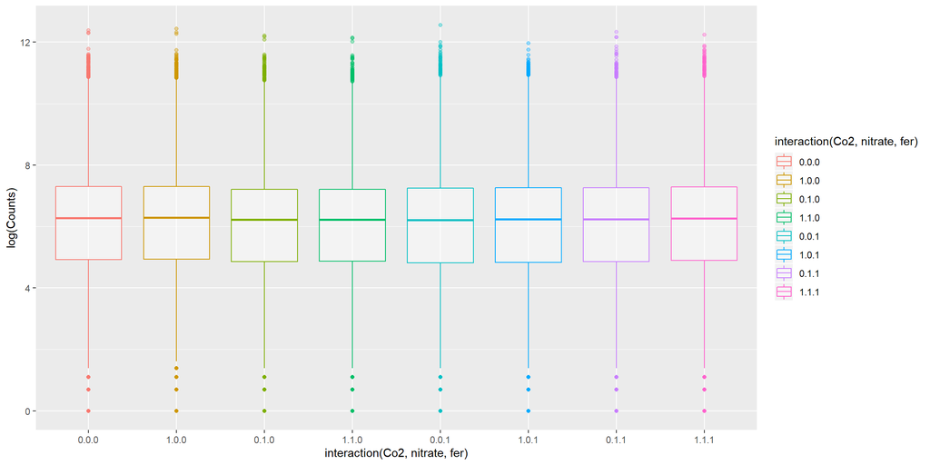

```r
ggplot(data = glmData, aes(x = interaction(Co2, nitrate, fer), y = log(Counts), color = interaction(Co2,
    nitrate, fer))) + geom_boxplot(alpha = 0.4)
```

```r
print(dim(glmData))
```

```
[1] 377016      5
```

```r
glm <- glm(Counts ~ 1 + as.factor(Co2) * as.factor(nitrate) * as.factor(fer), family = poisson(link = "log"),
    data = glmData)
summary(glm)
```

```
Call:
glm(formula = Counts ~ 1 + as.factor(Co2) * as.factor(nitrate) *
    as.factor(fer), family = poisson(link = "log"), data = glmData)

Deviance Residuals:
    Min       1Q   Median       3Q      Max
 -55.54   -45.34   -28.87    -1.22  1563.25

Coefficients:
                                                      Estimate Std. Error
(Intercept)                                          7.3411898  0.0001173
as.factor(Co2)1                                     -0.0131392  0.0001664
as.factor(nitrate)1                                 -0.0925671  0.0001698
as.factor(fer)1                                     -0.0797725  0.0001693
as.factor(Co2)1:as.factor(nitrate)1                 -0.0143272  0.0002414
as.factor(Co2)1:as.factor(fer)1                     -0.0086981  0.0002405
as.factor(nitrate)1:as.factor(fer)1                  0.0979767  0.0002420
as.factor(Co2)1:as.factor(nitrate)1:as.factor(fer)1  0.0637729  0.0003430
                                                     z value Pr(>|z|)
(Intercept)                                         62592.66   <2e-16 ***
as.factor(Co2)1                                       -78.95   <2e-16 ***
as.factor(nitrate)1                                  -545.02   <2e-16 ***
as.factor(fer)1                                      -471.26   <2e-16 ***
as.factor(Co2)1:as.factor(nitrate)1                   -59.34   <2e-16 ***
as.factor(Co2)1:as.factor(fer)1                       -36.17   <2e-16 ***
as.factor(nitrate)1:as.factor(fer)1                   404.87   <2e-16 ***
as.factor(Co2)1:as.factor(nitrate)1:as.factor(fer)1   185.93   <2e-16 ***
---
Signif. codes:  0 '***' 0.001 '**' 0.01 '*' 0.05 '.' 0.1 ' ' 1

(Dispersion parameter for poisson family taken to be 1)

    Null deviance: 1256191628  on 377015  degrees of freedom
Residual deviance: 1255318955  on 377008  degrees of freedom
AIC: 1258198536

Number of Fisher Scoring iterations: 6
```

```r
mixGlm <- glmer(Counts ~ as.factor(Co2) * as.factor(nitrate) * as.factor(fer) + (1 |
    gene), data = glmData, family = poisson(link = "log"))
summary(mixGlm)
```

```
Generalized linear mixed model fit by maximum likelihood (Laplace
  Approximation) [glmerMod]
 Family: poisson  ( log )
Formula: Counts ~ as.factor(Co2) * as.factor(nitrate) * as.factor(fer) +
    (1 | gene)
   Data: glmData

      AIC       BIC    logLik  deviance  df.resid
 54618620  54618717 -27309301  54618602    377007

Scaled residuals:
    Min      1Q  Median      3Q     Max
-239.91   -3.96   -0.49    3.43  490.79

Random effects:
 Groups Name        Variance Std.Dev.
 gene   (Intercept) 3.687    1.92
Number of obs: 377016, groups:  gene, 15709

Fixed effects:
                                                      Estimate Std. Error
(Intercept)                                          6.0049536  0.0148746
as.factor(Co2)1                                     -0.0131392  0.0001664
as.factor(nitrate)1                                 -0.0925671  0.0001698
as.factor(fer)1                                     -0.0797725  0.0001693
as.factor(Co2)1:as.factor(nitrate)1                 -0.0143270  0.0002414
as.factor(Co2)1:as.factor(fer)1                     -0.0086981  0.0002405
as.factor(nitrate)1:as.factor(fer)1                  0.0979767  0.0002420
as.factor(Co2)1:as.factor(nitrate)1:as.factor(fer)1  0.0637726  0.0003430
                                                    z value Pr(>|z|)
(Intercept)                                          403.71   <2e-16 ***
as.factor(Co2)1                                      -78.96   <2e-16 ***
as.factor(nitrate)1                                 -545.03   <2e-16 ***
as.factor(fer)1                                     -471.26   <2e-16 ***
as.factor(Co2)1:as.factor(nitrate)1                  -59.34   <2e-16 ***
as.factor(Co2)1:as.factor(fer)1                      -36.17   <2e-16 ***
as.factor(nitrate)1:as.factor(fer)1                  404.88   <2e-16 ***
as.factor(Co2)1:as.factor(nitrate)1:as.factor(fer)1  185.93   <2e-16 ***
---
Signif. codes:  0 '***' 0.001 '**' 0.01 '*' 0.05 '.' 0.1 ' ' 1

Correlation of Fixed Effects:
                        (Intr) as.(C2)1 as.fctr(n)1 as.fctr(f)1
as.fct(C2)1             -0.005
as.fctr(n)1             -0.005  0.487
as.fctr(f)1             -0.005  0.488    0.478
as.fctr(C2)1:s.fctr(n)1  0.004 -0.689   -0.703      -0.337
as.fctr(C2)1:s.fctr(f)1  0.004 -0.692   -0.337      -0.704
as.()1:.()1              0.004 -0.342   -0.702      -0.699
a.(C2)1:.()1:           -0.002  0.485    0.495       0.494
                        as.fctr(C2)1:s.fctr(n)1 as.fctr(C2)1:s.fctr(f)1 a.()1:
as.fct(C2)1
as.fctr(n)1
as.fctr(f)1
as.fctr(C2)1:s.fctr(n)1
as.fctr(C2)1:s.fctr(f)1  0.477
as.()1:.()1              0.494                   0.492
a.(C2)1:.()1:           -0.704                  -0.701                  -0.706
convergence code: 0
Model failed to converge with max|grad| = 0.00242054 (tol = 0.001, component 1)
Model is nearly unidentifiable: very large eigenvalue
 - Rescale variables?
```

On a ici une significativité de tous les coefficients. Ne serait-ce pas du au très grand nombre d’observations, qui rend tous les tests significatifs?

On va randomiser une variable (ici le nitrate), et voir si elle est toujours détectée comme significative.

```r
glmDataTest <- glmData
glmDataTest$nitrate <- sample(glmData$nitrate, replace = F)

glmTest <- glm(Counts ~ 1 + as.factor(Co2) * as.factor(nitrate) * as.factor(fer),
    family = poisson(link = "log"), data = glmDataTest)
summary(glmTest)
```

```
Call:
glm(formula = Counts ~ 1 + as.factor(Co2) * as.factor(nitrate) *
    as.factor(fer), family = poisson(link = "log"), data = glmDataTest)

Deviance Residuals:
    Min       1Q   Median       3Q      Max
 -54.62   -45.39   -28.90    -1.28  1563.47

Coefficients:
                                                      Estimate Std. Error
(Intercept)                                          7.2843236  0.0001207
as.factor(Co2)1                                     -0.0055055  0.0001710
as.factor(nitrate)1                                  0.0231647  0.0001697
as.factor(fer)1                                     -0.0163576  0.0001712
as.factor(Co2)1:as.factor(nitrate)1                 -0.0287392  0.0002411
as.factor(Co2)1:as.factor(fer)1                     -0.0048383  0.0002428
as.factor(nitrate)1:as.factor(fer)1                 -0.0308929  0.0002419
as.factor(Co2)1:as.factor(nitrate)1:as.factor(fer)1  0.0558467  0.0003428
                                                     z value Pr(>|z|)
(Intercept)                                         60356.44   <2e-16 ***
as.factor(Co2)1                                       -32.20   <2e-16 ***
as.factor(nitrate)1                                   136.53   <2e-16 ***
as.factor(fer)1                                       -95.56   <2e-16 ***
as.factor(Co2)1:as.factor(nitrate)1                  -119.18   <2e-16 ***
as.factor(Co2)1:as.factor(fer)1                       -19.93   <2e-16 ***
as.factor(nitrate)1:as.factor(fer)1                  -127.72   <2e-16 ***
as.factor(Co2)1:as.factor(nitrate)1:as.factor(fer)1   162.93   <2e-16 ***
---
Signif. codes:  0 '***' 0.001 '**' 0.01 '*' 0.05 '.' 0.1 ' ' 1

(Dispersion parameter for poisson family taken to be 1)

    Null deviance: 1256191628  on 377015  degrees of freedom
Residual deviance: 1256073042  on 377008  degrees of freedom
AIC: 1.259e+09

Number of Fisher Scoring iterations: 6
```

Elle l’est. (Ligne de l’effet nitrate toujours ***).

Je ne sais pas comment corriger ça, à part essayer d’enlever des observations, et ne pas dupliquer les gènes par example. On tente ça :

```r
glmData <- melt(round(normalized.count[DEgenes, ], 0))
glmData <- glmData[sample(rownames(glmData)), ]
colnames(glmData) <- c("gene", "Condition", "Counts")
glmData <- glmData[!duplicated(glmData$gene), ]
# On verifie que toutes les conditions soient bien représentées après le nouvel
# échantillonnage
summary(glmData$Condition)
```

```
cNF_3 cNF_2 cNF_1 cnF_2 cnF_1 cnF_3 CNF_1 CnF_2 CnF_1 CnF_3 cNf_1 cnf_2 cnf_1
  651   661   708   698   684   621   642   653   619   647   631   669   641
cNf_2 cNf_3 cnf_3 Cnf_3 CNf_1 Cnf_1 Cnf_2 CNf_3 CNf_2 CNF_3 CNF_2
  648   665   630   637   675   653   676   630   677   640   653
```

```r
groups <- str_split_fixed(glmData$Condition, "_", 2)[, 1]
glmData$Co2 <- str_split_fixed(groups, "", 3)[, 1]
glmData$nitrate <- str_split_fixed(groups, "", 3)[, 2]
glmData$fer <- str_split_fixed(groups, "", 3)[, 3]


glmData$Co2 <- ifelse(glmData$Co2 == "c", 0, 1)
glmData$nitrate <- ifelse(glmData$nitrate == "N", 0, 1)
glmData$fer <- ifelse(glmData$fer == "F", 0, 1)
glmData <- glmData[c("Counts", "Co2", "nitrate", "fer")]

head(glmData)
```

```
       Counts Co2 nitrate fer
353225    655   1       0   0
204972    176   0       0   1
153351   1639   1       1   0
33726     377   0       0   0
341466    229   1       0   1
49916     165   0       1   0
```

```r
print(dim(glmData))
```

```
[1] 15709     4
```

```r
glm <- glm(Counts ~ 1 + as.factor(Co2) * as.factor(nitrate) * as.factor(fer), family = poisson(link = "log"),
    data = glmData)
summary(glm)
```

```
Call:
glm(formula = Counts ~ 1 + as.factor(Co2) * as.factor(nitrate) *
    as.factor(fer), family = poisson(link = "log"), data = glmData)

Deviance Residuals:
    Min       1Q   Median       3Q      Max
 -54.96   -45.45   -28.96    -1.37  1159.27

Coefficients:
                                                      Estimate Std. Error
(Intercept)                                          7.2620841  0.0005894
as.factor(Co2)1                                      0.0388321  0.0008343
as.factor(nitrate)1                                  0.0578126  0.0008234
as.factor(fer)1                                      0.0177650  0.0008378
as.factor(Co2)1:as.factor(nitrate)1                 -0.0772237  0.0011770
as.factor(Co2)1:as.factor(fer)1                     -0.0194260  0.0011797
as.factor(nitrate)1:as.factor(fer)1                 -0.0271270  0.0011735
as.factor(Co2)1:as.factor(nitrate)1:as.factor(fer)1 -0.0713739  0.0016770
                                                     z value Pr(>|z|)
(Intercept)                                         12321.98   <2e-16 ***
as.factor(Co2)1                                        46.54   <2e-16 ***
as.factor(nitrate)1                                    70.21   <2e-16 ***
as.factor(fer)1                                        21.20   <2e-16 ***
as.factor(Co2)1:as.factor(nitrate)1                   -65.61   <2e-16 ***
as.factor(Co2)1:as.factor(fer)1                       -16.47   <2e-16 ***
as.factor(nitrate)1:as.factor(fer)1                   -23.12   <2e-16 ***
as.factor(Co2)1:as.factor(nitrate)1:as.factor(fer)1   -42.56   <2e-16 ***
---
Signif. codes:  0 '***' 0.001 '**' 0.01 '*' 0.05 '.' 0.1 ' ' 1

(Dispersion parameter for poisson family taken to be 1)

    Null deviance: 53495345  on 15708  degrees of freedom
Residual deviance: 53458650  on 15701  degrees of freedom
AIC: 53578628

Number of Fisher Scoring iterations: 6
```

C’est pareil. On essaie avec encore moins de gènes (1000 randomisé ou non, puis 100, randomisé ou non):

```r
glmData <- glmData[sample(rownames(glmData), size = 1000, replace = F), ]
glm <- glm(Counts ~ 1 + as.factor(Co2) * as.factor(nitrate) * as.factor(fer), family = poisson(link = "log"),
    data = glmData)
summary(glm)
```

```
Call:
glm(formula = Counts ~ 1 + as.factor(Co2) * as.factor(nitrate) *
    as.factor(fer), family = poisson(link = "log"), data = glmData)

Deviance Residuals:
   Min      1Q  Median      3Q     Max
-58.41  -42.52  -25.63    4.62  592.47

Coefficients:
                                                     Estimate Std. Error
(Intercept)                                          7.298392   0.002308
as.factor(Co2)1                                     -0.219201   0.003436
as.factor(nitrate)1                                  0.032058   0.003306
as.factor(fer)1                                     -0.298249   0.003421
as.factor(Co2)1:as.factor(nitrate)1                  0.330598   0.004657
as.factor(Co2)1:as.factor(fer)1                      0.128219   0.005198
as.factor(nitrate)1:as.factor(fer)1                  0.265247   0.004855
as.factor(Co2)1:as.factor(nitrate)1:as.factor(fer)1 -0.629797   0.007154
                                                     z value Pr(>|z|)
(Intercept)                                         3161.950   <2e-16 ***
as.factor(Co2)1                                      -63.790   <2e-16 ***
as.factor(nitrate)1                                    9.698   <2e-16 ***
as.factor(fer)1                                      -87.180   <2e-16 ***
as.factor(Co2)1:as.factor(nitrate)1                   70.990   <2e-16 ***
as.factor(Co2)1:as.factor(fer)1                       24.666   <2e-16 ***
as.factor(nitrate)1:as.factor(fer)1                   54.629   <2e-16 ***
as.factor(Co2)1:as.factor(nitrate)1:as.factor(fer)1  -88.038   <2e-16 ***
---
Signif. codes:  0 '***' 0.001 '**' 0.01 '*' 0.05 '.' 0.1 ' ' 1

(Dispersion parameter for poisson family taken to be 1)

    Null deviance: 2682577  on 999  degrees of freedom
Residual deviance: 2633070  on 992  degrees of freedom
AIC: 2640690

Number of Fisher Scoring iterations: 6
```

```r
glmDataTest <- glmData

glmDataTest$nitrate <- sample(glmDataTest$nitrate, replace = F)
glmTest <- glm(Counts ~ 1 + as.factor(Co2) * as.factor(nitrate) * as.factor(fer),
    family = poisson(link = "log"), data = glmDataTest)

summary(glmTest)
```

```
Call:
glm(formula = Counts ~ 1 + as.factor(Co2) * as.factor(nitrate) *
    as.factor(fer), family = poisson(link = "log"), data = glmDataTest)

Deviance Residuals:
   Min      1Q  Median      3Q     Max
-60.20  -42.20  -25.22    5.51  585.93

Coefficients:
                                                     Estimate Std. Error
(Intercept)                                          7.370259   0.002176
as.factor(Co2)1                                     -0.342159   0.003327
as.factor(nitrate)1                                 -0.128377   0.003344
as.factor(fer)1                                     -0.296256   0.003377
as.factor(Co2)1:as.factor(nitrate)1                  0.602424   0.004676
as.factor(Co2)1:as.factor(fer)1                      0.074368   0.005247
as.factor(nitrate)1:as.factor(fer)1                  0.255857   0.004885
as.factor(Co2)1:as.factor(nitrate)1:as.factor(fer)1 -0.543954   0.007190
                                                    z value Pr(>|z|)
(Intercept)                                         3387.20   <2e-16 ***
as.factor(Co2)1                                     -102.85   <2e-16 ***
as.factor(nitrate)1                                  -38.39   <2e-16 ***
as.factor(fer)1                                      -87.73   <2e-16 ***
as.factor(Co2)1:as.factor(nitrate)1                  128.84   <2e-16 ***
as.factor(Co2)1:as.factor(fer)1                       14.17   <2e-16 ***
as.factor(nitrate)1:as.factor(fer)1                   52.37   <2e-16 ***
as.factor(Co2)1:as.factor(nitrate)1:as.factor(fer)1  -75.66   <2e-16 ***
---
Signif. codes:  0 '***' 0.001 '**' 0.01 '*' 0.05 '.' 0.1 ' ' 1

(Dispersion parameter for poisson family taken to be 1)

    Null deviance: 2682577  on 999  degrees of freedom
Residual deviance: 2626325  on 992  degrees of freedom
AIC: 2633945

Number of Fisher Scoring iterations: 6
```

```r
glmData <- glmData[sample(rownames(glmData), size = 100, replace = F), ]
glm <- glm(Counts ~ 1 + as.factor(Co2) * as.factor(nitrate) * as.factor(fer), family = poisson(link = "log"),
    data = glmData)
summary(glm)
```

```
Call:
glm(formula = Counts ~ 1 + as.factor(Co2) * as.factor(nitrate) *
    as.factor(fer), family = poisson(link = "log"), data = glmData)

Deviance Residuals:
    Min       1Q   Median       3Q      Max
-50.832  -31.543  -14.842    7.167  150.881

Coefficients:
                                                    Estimate Std. Error z value
(Intercept)                                          6.72689    0.01044 644.519
as.factor(Co2)1                                     -0.48751    0.01609 -30.292
as.factor(nitrate)1                                 -0.33330    0.01717 -19.414
as.factor(fer)1                                      0.25558    0.01324  19.308
as.factor(Co2)1:as.factor(nitrate)1                  0.64643    0.02299  28.113
as.factor(Co2)1:as.factor(fer)1                      0.66739    0.01951  34.206
as.factor(nitrate)1:as.factor(fer)1                 -0.15189    0.02299  -6.607
as.factor(Co2)1:as.factor(nitrate)1:as.factor(fer)1 -0.09430    0.02956  -3.190
                                                    Pr(>|z|)
(Intercept)                                          < 2e-16 ***
as.factor(Co2)1                                      < 2e-16 ***
as.factor(nitrate)1                                  < 2e-16 ***
as.factor(fer)1                                      < 2e-16 ***
as.factor(Co2)1:as.factor(nitrate)1                  < 2e-16 ***
as.factor(Co2)1:as.factor(fer)1                      < 2e-16 ***
as.factor(nitrate)1:as.factor(fer)1                 3.92e-11 ***
as.factor(Co2)1:as.factor(nitrate)1:as.factor(fer)1  0.00142 **
---
Signif. codes:  0 '***' 0.001 '**' 0.01 '*' 0.05 '.' 0.1 ' ' 1

(Dispersion parameter for poisson family taken to be 1)

    Null deviance: 140450  on 99  degrees of freedom
Residual deviance: 129971  on 92  degrees of freedom
AIC: 130724

Number of Fisher Scoring iterations: 6
```

```r
glmDataTest <- glmData

glmDataTest$nitrate <- sample(glmDataTest$nitrate, replace = F)
glmTest <- glm(Counts ~ 1 + as.factor(Co2) * as.factor(nitrate) * as.factor(fer),
    family = poisson(link = "log"), data = glmDataTest)
summary(glmTest)
```

```
Call:
glm(formula = Counts ~ 1 + as.factor(Co2) * as.factor(nitrate) *
    as.factor(fer), family = poisson(link = "log"), data = glmDataTest)

Deviance Residuals:
    Min       1Q   Median       3Q      Max
-61.752  -32.933   -8.378    7.872  127.796

Coefficients:
                                                     Estimate Std. Error
(Intercept)                                          6.670495   0.009516
as.factor(Co2)1                                      0.183200   0.012511
as.factor(nitrate)1                                 -0.296322   0.019358
as.factor(fer)1                                      0.162753   0.014082
as.factor(Co2)1:as.factor(nitrate)1                 -1.058450   0.027073
as.factor(Co2)1:as.factor(fer)1                     -0.593606   0.019990
as.factor(nitrate)1:as.factor(fer)1                  0.271774   0.023820
as.factor(Co2)1:as.factor(nitrate)1:as.factor(fer)1  2.213268   0.033104
                                                    z value Pr(>|z|)
(Intercept)                                          700.97   <2e-16 ***
as.factor(Co2)1                                       14.64   <2e-16 ***
as.factor(nitrate)1                                  -15.31   <2e-16 ***
as.factor(fer)1                                       11.56   <2e-16 ***
as.factor(Co2)1:as.factor(nitrate)1                  -39.10   <2e-16 ***
as.factor(Co2)1:as.factor(fer)1                      -29.70   <2e-16 ***
as.factor(nitrate)1:as.factor(fer)1                   11.41   <2e-16 ***
as.factor(Co2)1:as.factor(nitrate)1:as.factor(fer)1   66.86   <2e-16 ***
---
Signif. codes:  0 '***' 0.001 '**' 0.01 '*' 0.05 '.' 0.1 ' ' 1

(Dispersion parameter for poisson family taken to be 1)

    Null deviance: 140450  on 99  degrees of freedom
Residual deviance: 116064  on 92  degrees of freedom
AIC: 116817

Number of Fisher Scoring iterations: 6
```

## Sur des clusters de gènes

# Sur les gènes répondant au CO2

Dans au moins 3 des 4 comparaisons possibles de transcriptomes avec changement de CO2

# En prenant tous les gènes

```r
load("./normalized.count_At.RData")
load("./GenesCO2_At.RData")
load("./DEgenesAllAt.RData")
load("GenesCO2_clustered_coseq_At.RData")

DEgenes <- sharedBy3

glmData <- melt(round(normalized.count[DEgenes, ], 0))
colnames(glmData) <- c("gene", "Condition", "Counts")
glmData <- glmData[sample(rownames(glmData)), ]
# glmData <- glmData[!duplicated(glmData$gene),]

groups <- str_split_fixed(glmData$Condition, "_", 2)[, 1]
glmData$Co2 <- str_split_fixed(groups, "", 3)[, 1]
glmData$nitrate <- str_split_fixed(groups, "", 3)[, 2]
glmData$fer <- str_split_fixed(groups, "", 3)[, 3]


glmData$Co2 <- ifelse(glmData$Co2 == "c", 0, 1)
glmData$nitrate <- ifelse(glmData$nitrate == "N", 0, 1)
glmData$fer <- ifelse(glmData$fer == "F", 0, 1)
glmData <- glmData[c("Counts", "Co2", "nitrate", "fer", "gene")]

head(glmData)
```

```
     Counts Co2 nitrate fer      gene
273    2891   0       0   0 AT5G37690
51     2709   0       0   0 AT5G05500
262     165   0       0   0 AT1G55790
336     553   0       0   0 AT2G45180
598     571   0       1   0 AT2G45180
1974   3146   0       1   1 AT2G39980
```

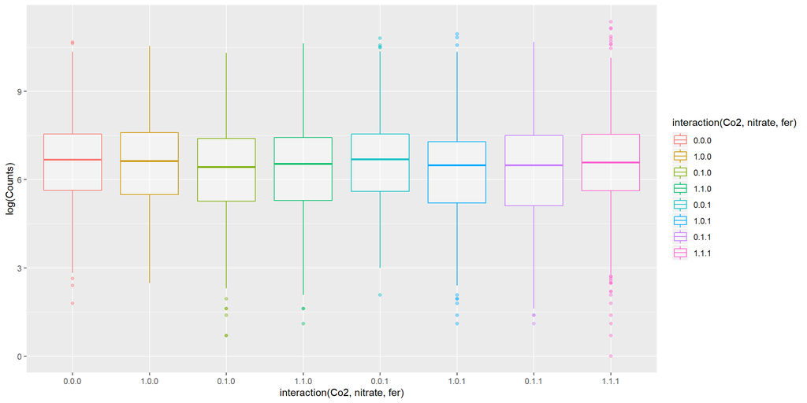

```r
ggplot(data = glmData, aes(x = interaction(Co2, nitrate, fer), y = log(Counts), color = interaction(Co2,
    nitrate, fer))) + geom_boxplot(alpha = 0.4)
```

```r
print(dim(glmData))
```

```
[1] 3144    5
```

```r
glm <- glm(Counts ~ 1 + as.factor(Co2) * as.factor(nitrate) * as.factor(fer), family = poisson(link = "log"),
    data = glmData)
summary(glm)
```

```
Call:
glm(formula = Counts ~ 1 + as.factor(Co2) * as.factor(nitrate) *
    as.factor(fer), family = poisson(link = "log"), data = glmData)

Deviance Residuals:
   Min      1Q  Median      3Q     Max
-76.50  -55.34  -38.60   -9.29  648.59

Coefficients:
                                                     Estimate Std. Error
(Intercept)                                          7.764011   0.001040
as.factor(Co2)1                                     -0.114374   0.001514
as.factor(nitrate)1                                 -0.300003   0.001594
as.factor(fer)1                                      0.104602   0.001433
as.factor(Co2)1:as.factor(nitrate)1                  0.256472   0.002240
as.factor(Co2)1:as.factor(fer)1                     -0.078797   0.002109
as.factor(nitrate)1:as.factor(fer)1                  0.272705   0.002124
as.factor(Co2)1:as.factor(nitrate)1:as.factor(fer)1  0.079966   0.003006
                                                    z value Pr(>|z|)
(Intercept)                                         7468.21   <2e-16 ***
as.factor(Co2)1                                      -75.54   <2e-16 ***
as.factor(nitrate)1                                 -188.25   <2e-16 ***
as.factor(fer)1                                       72.98   <2e-16 ***
as.factor(Co2)1:as.factor(nitrate)1                  114.50   <2e-16 ***
as.factor(Co2)1:as.factor(fer)1                      -37.37   <2e-16 ***
as.factor(nitrate)1:as.factor(fer)1                  128.36   <2e-16 ***
as.factor(Co2)1:as.factor(nitrate)1:as.factor(fer)1   26.60   <2e-16 ***
---
Signif. codes:  0 '***' 0.001 '**' 0.01 '*' 0.05 '.' 0.1 ' ' 1

(Dispersion parameter for poisson family taken to be 1)

    Null deviance: 17315940  on 3143  degrees of freedom
Residual deviance: 17142855  on 3136  degrees of freedom
AIC: 17168893

Number of Fisher Scoring iterations: 6
```

```r
mixGlm <- glmer(Counts ~ as.factor(Co2) * as.factor(nitrate) * as.factor(fer) + (1 |
    gene), data = glmData, family = poisson(link = "log"))
summary(mixGlm)
```

```
Generalized linear mixed model fit by maximum likelihood (Laplace
  Approximation) [glmerMod]
 Family: poisson  ( log )
Formula: Counts ~ as.factor(Co2) * as.factor(nitrate) * as.factor(fer) +
    (1 | gene)
   Data: glmData

     AIC      BIC   logLik deviance df.resid
 2396116  2396170 -1198049  2396098     3135

Scaled residuals:
     Min       1Q   Median       3Q      Max
-106.784  -13.280   -2.884   10.350  184.463

Random effects:
 Groups Name        Variance Std.Dev.
 gene   (Intercept) 1.76     1.327
Number of obs: 3144, groups:  gene, 131

Fixed effects:
                                                     Estimate Std. Error
(Intercept)                                          6.796432   0.116007
as.factor(Co2)1                                     -0.114374   0.001514
as.factor(nitrate)1                                 -0.300003   0.001594
as.factor(fer)1                                      0.104602   0.001433
as.factor(Co2)1:as.factor(nitrate)1                  0.256472   0.002240
as.factor(Co2)1:as.factor(fer)1                     -0.078797   0.002109
as.factor(nitrate)1:as.factor(fer)1                  0.272705   0.002124
as.factor(Co2)1:as.factor(nitrate)1:as.factor(fer)1  0.079966   0.003006
                                                    z value Pr(>|z|)
(Intercept)                                           58.59   <2e-16 ***
as.factor(Co2)1                                      -75.54   <2e-16 ***
as.factor(nitrate)1                                 -188.25   <2e-16 ***
as.factor(fer)1                                       72.98   <2e-16 ***
as.factor(Co2)1:as.factor(nitrate)1                  114.50   <2e-16 ***
as.factor(Co2)1:as.factor(fer)1                      -37.37   <2e-16 ***
as.factor(nitrate)1:as.factor(fer)1                  128.36   <2e-16 ***
as.factor(Co2)1:as.factor(nitrate)1:as.factor(fer)1   26.60   <2e-16 ***
---
Signif. codes:  0 '***' 0.001 '**' 0.01 '*' 0.05 '.' 0.1 ' ' 1

Correlation of Fixed Effects:
                        (Intr) as.(C2)1 as.fctr(n)1 as.fctr(f)1
as.fct(C2)1             -0.006
as.fctr(n)1             -0.006  0.448
as.fctr(f)1             -0.006  0.498    0.473
as.fctr(C2)1:s.fctr(n)1  0.004 -0.676   -0.711      -0.337
as.fctr(C2)1:s.fctr(f)1  0.004 -0.718   -0.322      -0.680
as.()1:.()1              0.004 -0.336   -0.750      -0.675
a.(C2)1:.()1:           -0.003  0.504    0.530       0.477
                        as.fctr(C2)1:s.fctr(n)1 as.fctr(C2)1:s.fctr(f)1 a.()1:
as.fct(C2)1
as.fctr(n)1
as.fctr(f)1
as.fctr(C2)1:s.fctr(n)1
as.fctr(C2)1:s.fctr(f)1  0.485
as.()1:.()1              0.534                   0.459
a.(C2)1:.()1:           -0.745                  -0.701                  -0.707
convergence code: 0
Model is nearly unidentifiable: very large eigenvalue
 - Rescale variables?
```

A work by [Océane Cassan](https://oceanecsn.github.io/)

*oceane.cassan@supagro.fr*